# Predictive modeling and Regression analysis on adult census income data

### 3.3.1 Univariate Analysis

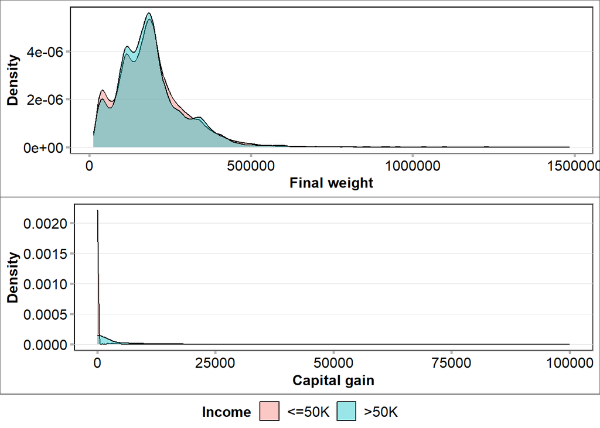

1. Density plot of numeric features w.r.t to Income categories

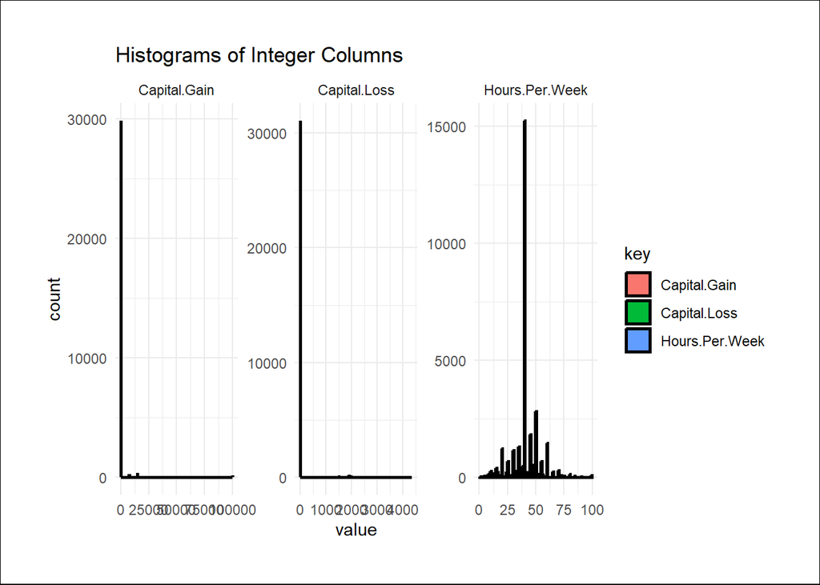

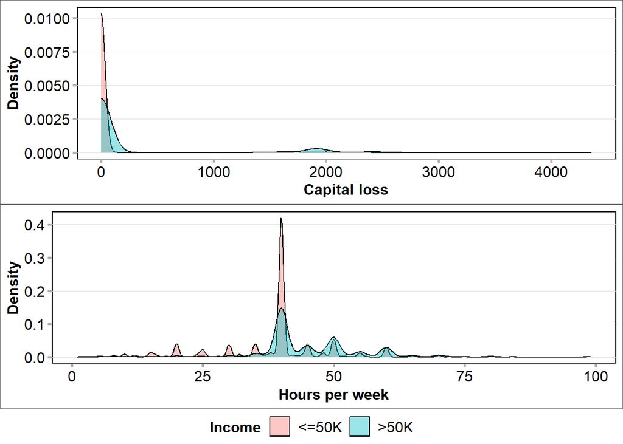

2. Density plot of numeric features w.r.t to income categories

The exploratory data analysis using mosaic plots highlighted key insights into the relationship (association) between categorical features and income categories. Notably, the “Age category” exhibited minimal or no variation among income categories, indicating a lack of association or a weak one at best. Consequently, this feature will be excluded from further analysis due to its limited discriminatory power regarding income levels. Conversely, other categorical features showcased significant variations in their categories across different income groups, suggesting a strong impact of income changes on these features. Therefore, excluding “Age category”, the remaining categorical features will be retained for the subsequent feature selection stage due to their apparent influence on distinguishing income categories. These categorical variables are further undergone one-hot encoding to treat each category of each feature as a separate dummy variable.

## 3.3.2 Bivariate Analysis

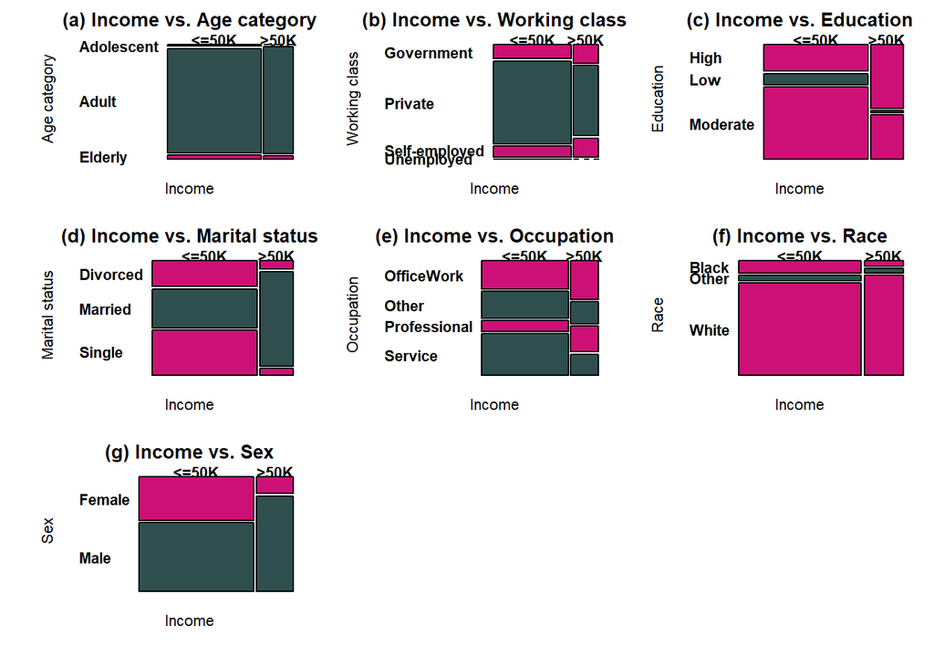

2. Mosaic plot to observe the association between categorical features and Income categories

```
##                       FNLWGT  Capital.Gain Capital.Loss Hours.Per.Week
## FNLWGT          1.0000000000  0.0004318858  -0.01025171    -0.01876849
## Capital.Gain    0.0004318858  1.0000000000  -0.03161506     0.07840862
## Capital.Loss   -0.0102517117 -0.0316150630   1.00000000     0.05425636
## Hours.Per.Week -0.0187684906  0.0784086154   0.05425636     1.00000000
```

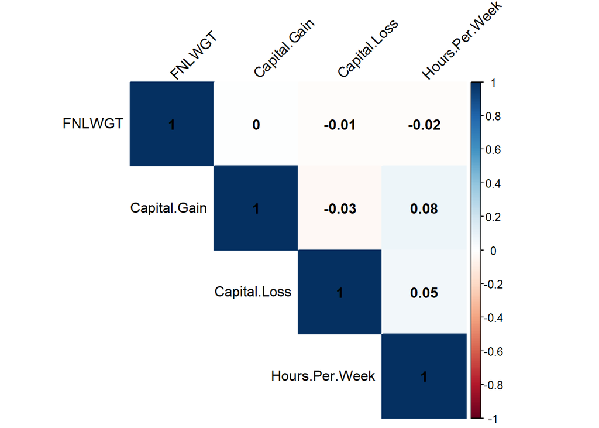

```
##                 Age Category     Workclass   Education Marital.Status
## Age Category    1.0000000000  0.0405539933  0.09785205  -0.0002658557
## Workclass       0.0405539933  1.0000000000  0.00410733  -0.0197299259
## Education       0.0978520538  0.0041073302  1.00000000  -0.0384069188
## Marital.Status -0.0002658557 -0.0197299259 -0.03840692   1.0000000000
## Occupation     -0.0078289540  0.0102799406 -0.03638484   0.0227518036
## Relationship   -0.1123773254 -0.0571134247 -0.01087610   0.1854509701
## Race            0.0123230678  0.0455355715  0.01413125  -0.0680130622
## Sex             0.0163527058  0.0669766167 -0.02735624  -0.1293144674
## Native.Country -0.0032765093 -0.0001588804  0.07556511  -0.0214584836
## income          0.0162960519  0.0007544867  0.07931661  -0.1993070092
##                  Occupation Relationship         Race          Sex
## Age Category   -0.007828954  -0.11237733  0.012323068  0.016352706
## Workclass       0.010279941  -0.05711342  0.045535572  0.066976617
## Education      -0.036384835  -0.01087610  0.014131249 -0.027356238
## Marital.Status  0.022751804   0.18545097 -0.068013062 -0.129314467
## Occupation      1.000000000  -0.04987926 -0.002390575  0.058427997
## Relationship   -0.049879259   1.00000000 -0.116054596 -0.582453690
## Race           -0.002390575  -0.11605460  1.000000000  0.087204302
## Sex             0.058427997  -0.58245369  0.087204302  1.000000000
## Native.Country -0.006144170  -0.01200044  0.118563987  0.002664716
## income          0.049101172  -0.25091814  0.071845611  0.215980151
##                Native.Country        income
## Age Category    -0.0032765093  0.0162960519
## Workclass       -0.0001588804  0.0007544867
## Education        0.0755651081  0.0793166093
## Marital.Status  -0.0214584836 -0.1993070092
## Occupation      -0.0061441702  0.0491011715
## Relationship    -0.0120004418 -0.2509181417
## Race             0.1185639869  0.0718456115
## Sex              0.0026647157  0.2159801506
## Native.Country   1.0000000000  0.0235744671
## income           0.0235744671  1.0000000000
```

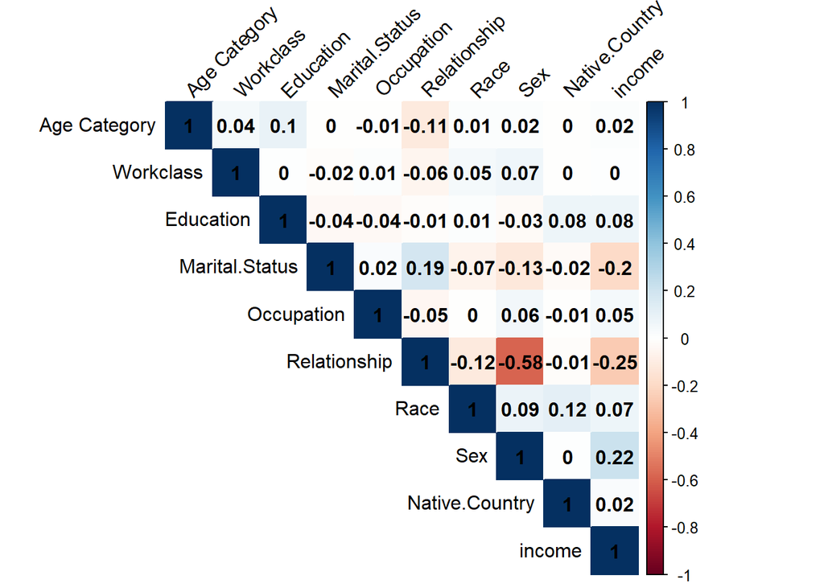

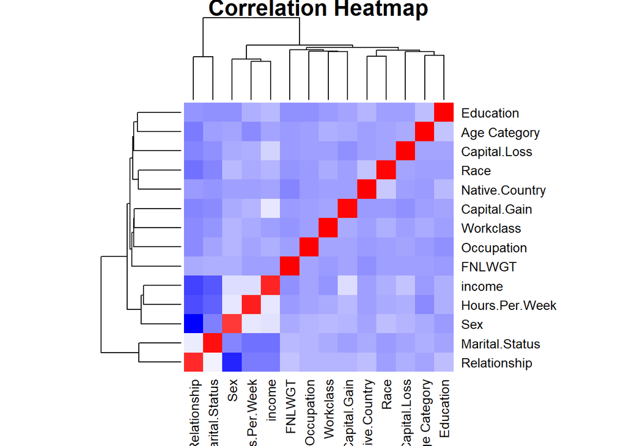